# Model selection, cross validation, and performance of time series models

January 29 2019

## Overview of today’s material

- Approaches for model selection
- Cross validation
- Quantifying forecast performance

## How good are our models?

Several candidate models might be built based on

- hypotheses / mechanisms
- diagnostics / summaries of fit

Models can be evaluated by their ability to explain data

- OR by the tradeoff in the ability to explain data, and ability to predict future data
- OR just in their predictive abilities
  - Hindcasting
  - Forecasting

## How good are our models?

We can illustrate with an example to the `harborSealWA` dataset in MARSS

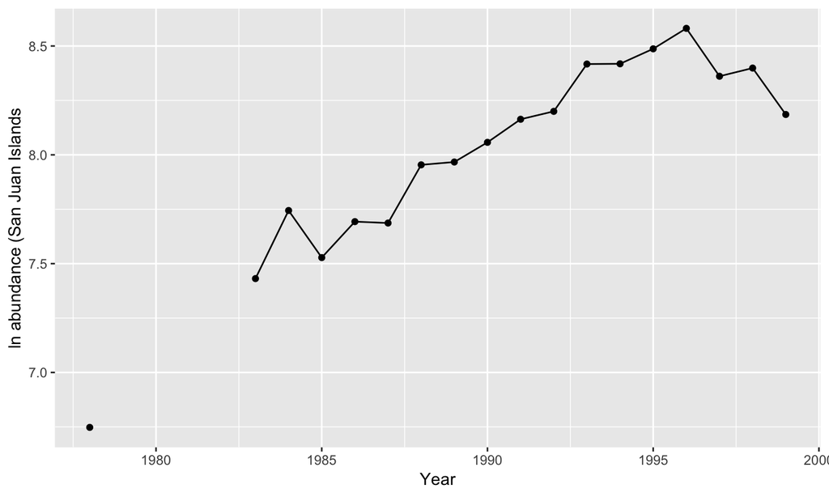

## How good are our models?

Metrics like the sum of squares are appealing,

\[SS=\sum _{ i=1 }^{ n }{ { \left( y_{ i }-E[{ y }_{ i }] \right) }^{ 2 } } \]

## How good are our models?

```
##
## Call:
## lm(formula = SJI ~ Year, data = harborSealWA)
##
## Residuals:
##      Min       1Q   Median       3Q      Max
## -0.46099 -0.08022  0.06576  0.13286  0.21464
##
## Coefficients:
##               Estimate Std. Error t value Pr(>|t|)
## (Intercept) -1.392e+02  1.601e+01  -8.697 1.85e-07 ***
## Year         7.397e-02  8.043e-03   9.197 8.69e-08 ***
## ---
## Signif. codes:  0 '***' 0.001 '**' 0.01 '*' 0.05 '.' 0.1 ' ' 1
##
## Residual standard error: 0.1916 on 16 degrees of freedom
##   (4 observations deleted due to missingness)
## Multiple R-squared:  0.8409, Adjusted R-squared:  0.831
## F-statistic: 84.58 on 1 and 16 DF,  p-value: 8.693e-08
```

## How good are our models?

Our regression model had a pretty good sum-of-squares

- But SS is problematic
  - as we consider more complex models, they’ll inevitably reduce SS
  - there’s no cost or penalty for having too many parameters

## Model selection

Lots of metrics have been developed to overcome this issue and penalize complex models

- **Occam’s razor**: “the law of briefness”
- **Principle of parsimony**: choose the simplest possible model that explains the data pretty well
  - choose a model that minimizes bias *and* variance

## Model selection

[figure not shown]

https://doi.org/10.1016/j.tree.2006.10.004

## Model selection: AIC

Akaike’s Information Criterion (**AIC**, Akaike 1973)

- Attempts to balance the goodness of fit of the model against the number of parameters
- Based on deviance = minus twice negative log likelihood

Deviance = \[-2\cdot ln\left( L(\underline { \theta } |\underline { y } ) \right)\]

- Deviance is a measure of model fit to data
  - lower values are better
  - Maximizing likelihood is equivalent to minimizing negative likelihood

## Model selection: AIC

Many *IC approaches to model selection also rely on deviance. Where they differ is how they structure the penalty term.

For AIC, the penalty is 2 * number of parameters (\(k\)),

\[AIC = -2\cdot ln\left( L(\underline { \theta } |\underline { y } ) \right) + 2k\]

- But what about sample size, \(n\)?

## Model selection: AIC

Small sample AIC

\[AICc=AIC+\frac { 2k(k+1) }{ n-k-1 }\]

- What happens to this term as n increases?

## Model selection: AIC

AIC aims to find the best model to predict data generated from the same process that generated your observations

- Equivalent to significance test w/ \(\alpha\) = 0.16

Alternative: Schwarz/Bayesian Information Criterion (SIC/BIC)

- Not Bayesian!
- Relies on Laplace approximation to posterior
- \(\alpha\) becomes a function of sample size

## Model selection: AIC

BIC is measure of explanatory power (rather than balancing explanation / prediction)

\[BIC = -2\cdot ln\left( L(\underline { \theta } |\underline { y } ) \right) + k\cdot ln(n)\]

## Model selection: AIC

Philosophical differences between AIC / BIC

- AIC / AICc tries to choose a model that approximates reality
  - does not assume that reality exists in your set of candidate models
- BIC assumes that one of your models is truth
  - This model will tend to be favored more as sample size increases

## Model selection: AIC

Many base functions in R support the extraction of AIC

```r
y = cumsum(rnorm(20))
AIC(lm(y~1))
AIC(glm(y~1))
AIC(mgcv::gam(y~1))
AIC(glmmTMB::glmmTMB(y~1))
AIC(lme4::lmer(y~1))
AIC(stats::arima(y))
AIC(forecast::Arima(y))
```

## Bayesian model selection

Largely beyond the scope of this class, but as an overview there’s several options

- Bayes factors (approximated by BIC)
  - can be very difficult to calculate for complex models
- Deviance Information Criterion (DIC)
  - Spiegelhalter et al. (2002)
  - DIC is easy to get out of some programs (JAGS)

DIC is also attempting to balance bias and variance

## Bayesian model selection

Like AIC, DIC is estimated from (1) the deviance, and (2) penalty, or effective number of parameters \(p_{D}\). \[DIC = -2\cdot ln\left( L(\underline { \theta } |\underline { y } ) \right) + 2p_{D}\] Options for \(p_{D}\) are

- \(E[D]-D\left( \bar { \theta } \right)\) (Spiegelhalter et al. 2002) and
- \(\frac { Var(D\left( \theta \right) ) }{ 2 }\) (Gelman et al. 2004)

## Bayesian model selection

The big difference between the Bayesian and maximum likelihood approaches are that

- ML methods are maximizing the likelihood over the parameter space
- Bayesian methods are integrating over the parameter space, asking ‘what values are best, on average?’

Many of the ML methods discussed were designed for models with only fixed effects.

- What about correlated parameters, nested or hierarchical models?

## Cross validation

Recent focus in ecology & fisheries on prediction

[Dietze et al. 2017](https://esajournals.onlinelibrary.wiley.com/doi/full/10.1002/eap.1589)

[Maris et al. 2017](https://onlinelibrary.wiley.com/doi/full/10.1111/oik.04655)

[Pennekamp et al. 2017](https://www.sciencedirect.com/science/article/pii/S1476945X16301106)

[Pennekamp et al. 2018](https://www.biorxiv.org/content/early/2018/06/19/350017)

[Szuwalkski & Thorson 2017](https://onlinelibrary.wiley.com/doi/abs/10.1111/faf.12226)

[Anderson et al. 2017](https://onlinelibrary.wiley.com/doi/abs/10.1111/faf.12200)

## Resampling techniques

**Jackknife**

- Hold out each data point, recomputing some statistic (and then average across 1:n)

**Bootstrap**

- Similar to jackknife, but with resampling

**Cross-validation (k-fold)**

- Divide dataset into k-partitions
- How well do (k-1) partitions predict kth set of points?
- Relationship between LOOCV and AIC

**Data split**: test/training sets (e.g. holdout last 5 data pts)

## Resampling techniques

Bootstrap or jackknife approaches are useful

- generally used in the context of time series models to generate new or pseudo-datasets
- state space models: use estimated deviations / errors to simulate, estimate CIs

Examples

```r
MARSS::MARSSboot()
MARSS::MARSSinnovationsboot()
forecast::bld.mbb.bootstrap()
forecast::forecast(..., bootstrap=TRUE)
```

## Resampling techniques

As an example, we’ll use a time series of body temperature from the `beavers` dataset

```r
data(beavers)
beaver = dplyr::filter(beaver2, time>200)
```

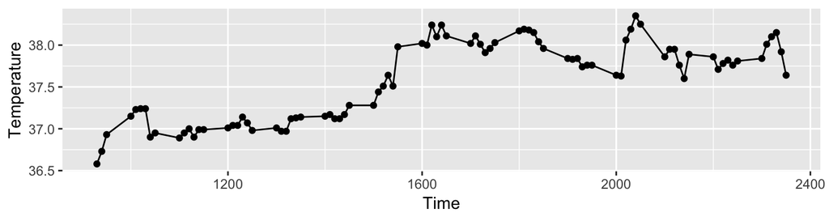

```r
ggplot(beaver, aes(time, temp)) +
  geom_point() + geom_line() +
  ylab("Temperature") + xlab("Time")
```

## Resampling techniques: K-fold cross validation

- Choose model (e.g. regression)
- Partition data
- Fit & prediction

Things to highlight: # folds, how sampling is done

```r
K = 5
beaver$part = sample(1:K, size=nrow(beaver), replace=T)
beaver$pred = 0
for(i in 1:K) {
    mod = lm(temp~time, data = beaver[beaver$part!=i,])
    beaver$pred[beaver$part==i] =
    predict(mod, newdata = beaver[beaver$part==i,])
}
```

## Resampling techniques: K-fold cross validation

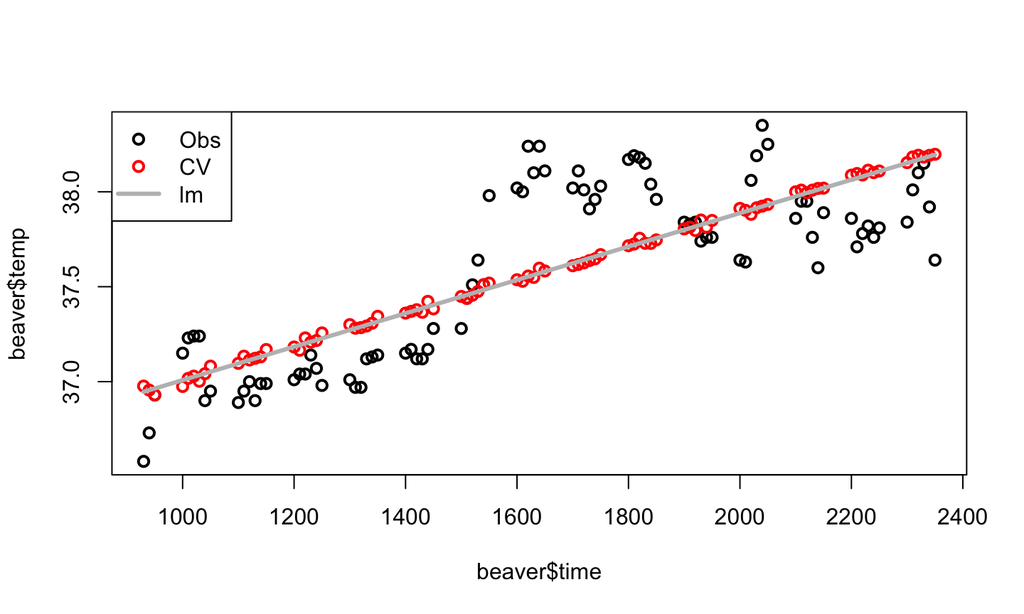

## Resampling techniques: K-fold cross validation

- How large should K be?
- Bias/variance tradeoff:
- Low K: low variance, larger bias, quicker to run. ML approaches recommend 5-10
- High K (LOOCV): low bias, high variance, computationally expensive

## Resampling techniques: repeated K-fold cross validation

- To remove effect of random sampling / partitioning, repeat K-fold cross validation and average predictions for a given data point
- caret() package in R

## Resampling techniques: repeated K-fold cross validation

- Need to specify repeats

```r
train_control = caret::trainControl(method="repeatedcv",
                number=5, repeats=20)
```

- Again this is extendable across many widely used models

## Resampling techniques: repeated K-fold cross validation

```r
summary(model)
```

Call: lm(formula = .outcome ~ ., data = dat)

Residuals: Min 1Q Median 3Q Max -0.5553 -0.2160 -0.1019 0.2139 0.6868

Residual standard error: 0.2905 on 85 degrees of freedom Multiple R-squared: 0.6218, Adjusted R-squared: 0.6173 F-statistic: 139.7 on 1 and 85 DF, p-value: < 2.2e-16

## Resampling techniques

What about for time series data?

- Previous resampling was random
- No preservation of order (autocorrelation)

## Resampling techniques: forward chain CV

Idea: only evaluate models on subsequent data

- Fold 1: training[1], test[2]
- Fold 2: training[1:2], test[3]
- Fold 3: training[1:3], test[4]
- Fold 4: training[1:4], test[5]

## Resampling techniques: forward chain CV

Example with Arima(1,1,1) model

- Assign partitions in order, 1:5

```r
beaver$part = ceiling(5*seq(1,nrow(beaver)) / (nrow(beaver)))
```

- iterate through 2:5 fitting the model and forecasting

## Resampling techniques: forward chain CV

Example code:

```r
for(i in 2:5) {
mod = Arima(beaver$temp[which(beaver$part < i)], order=c(1,1,1))

beaver$pred[which(beaver$part == i)] =
  as.numeric(forecast(mod, h = length(which(beaver$part == i)))$mean)
}
```

## Bayesian cross validation

LOOCV (Leave-one out cross validation) + preferred over alternatives

WAIC (widely applicable information criterion)

- Both available in `loo::loo()`

Additional reading: https://cran.r-project.org/web/packages/loo/vignettes/loo2-example.html

## Prediction and forecast evaluations

## Forecasting with arima()

- Let’s fit an ARMA(1,1) model to the global temperature data, after 1st differencing to remove trend
- You can use the arima() function or Arima() function – Arima() is a wrapper for arima()

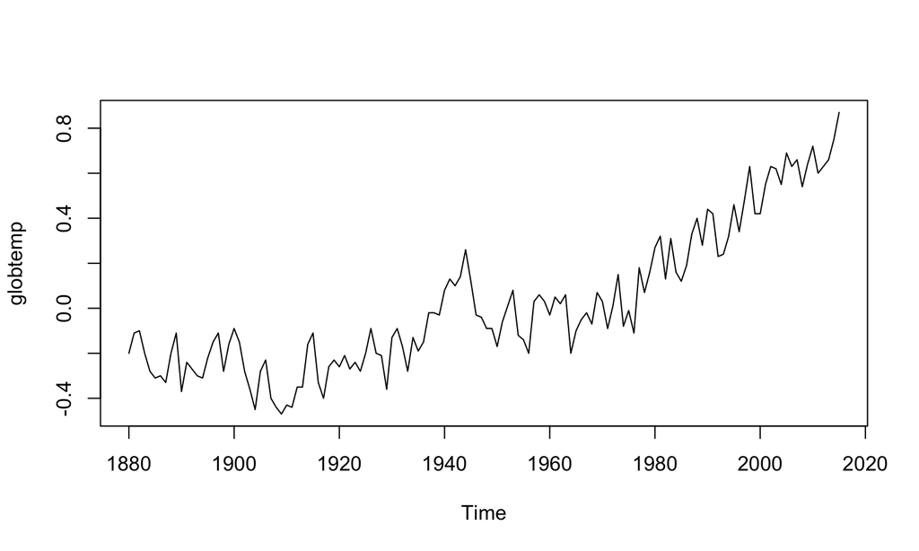

## Forecasting with arima()

Seasonal component not included because these data are collected annually

```r
ar.global.1 = Arima(globtemp, order = c(1,1,1),
              seasonal=list(order=c(0,0,0),
              period=12))

f1 = forecast(ar.global.1, h = 10)
```

- h = number of time steps to forecast in future

## Forecasting with arima()

```r
summary(f1)
```

```
##
## Forecast method: ARIMA(1,1,1)
##
## Model Information:
## Series: globtemp
## ARIMA(1,1,1)
##
## Coefficients:
##          ar1      ma1
##       0.3138  -0.6975
## s.e.  0.1400   0.0989
##
## sigma^2 estimated as 0.01035:  log likelihood=117.81
## AIC=-229.62   AICc=-229.44   BIC=-220.91
##
## Error measures:
##                      ME      RMSE        MAE      MPE     MAPE      MASE
## Training set 0.01578913 0.1006282 0.08541372 20.22738 76.15972 0.9569172
##                     ACF1
## Training set 0.002808596
##
## Forecasts:
##      Point Forecast     Lo 80     Hi 80     Lo 95     Hi 95
## 2016      0.7942681 0.6638616 0.9246747 0.5948285 0.9937078
## 2017      0.7705020 0.6173184 0.9236855 0.5362279 1.0047760
## 2018      0.7630437 0.5967695 0.9293178 0.5087493 1.0173381
## 2019      0.7607031 0.5840228 0.9373834 0.4904939 1.0309123
## 2020      0.7599686 0.5739514 0.9459858 0.4754799 1.0444574
## 2021      0.7597381 0.5649751 0.9545011 0.4618738 1.0576024
## 2022      0.7596658 0.5565764 0.9627551 0.4490674 1.0702641
## 2023      0.7596431 0.5485686 0.9707176 0.4368325 1.0824537
## 2024      0.7596359 0.5408715 0.9784004 0.4250646 1.0942073
## 2025      0.7596337 0.5334418 0.9858256 0.4137030 1.1055644
```

## Forecasting with arima()

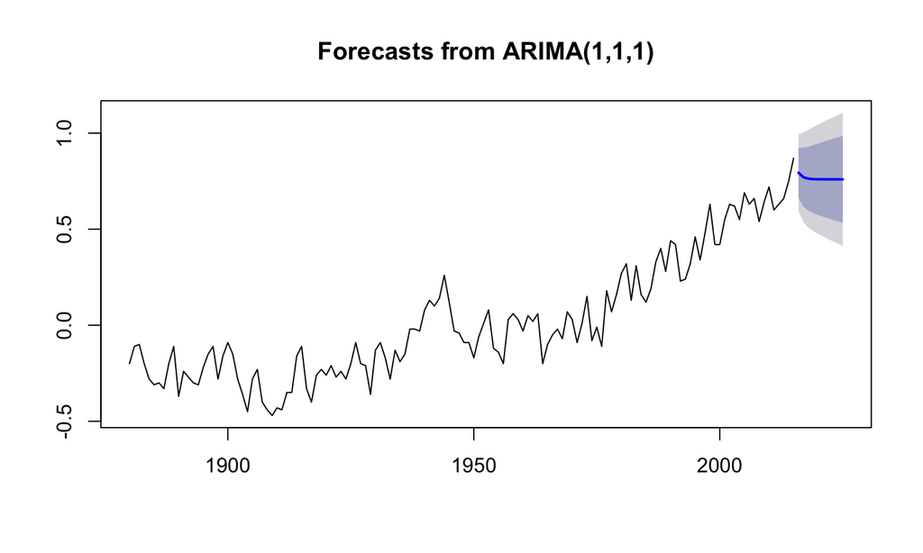

```r
plot(f1)
```

## Quantifying forecast performance

One of the most widelty used metrics is mean square error (MSE)

\[MSE=E\left[ { e }_{ t }^{ 2 } \right] =E\left[ { \left( { x }_{ t }-{ \hat { x } }_{ t } \right) }^{ 2 } \right]\]

- Root mean squared error (RMSE) also very common

## Quantifying forecast performance

Like with model selection, the bias-variance tradeoff is important

- principle of parsimony

MSE can be rewritten as

\[MSE=Var\left( { \hat { x } }_{ t } \right) +Bias{ \left( { x }_{ t },{ \hat { x } }_{ t } \right) }^{ 2 }\] * Smaller MSE = lower bias + variance

## Quantifying forecast performance

MSE and all forecast metrics can be calculated for

- single data points
- entire time series
- future forecasts

\[MSE={ \frac { \sum _{ t=1 }^{ n }{ { \left( { x }_{ t }-{ \hat { x } }_{ t } \right) }^{ 2 } } }{ n } }\]

- Do you care just about predicting the final outcome of a forecast, or also the trajectory to get there?

## Variants of MSE

Root mean square error, RMSE (quadratic score)

Mean absolute error, MAE (linear score) \[E\left[ \left| { x }_{ t }-{ \hat { x } }_{ t } \right| \right]\]

Median absolute error, MdAE

\[median\left[ \left| { x }_{ t }-{ \hat { x } }_{ t } \right| \right]\]

## Scale independent measures of performance

Better when applying statistics of model(s) to multiple datasets MSE or RMSE will be driven by time series that is larger in magnitude

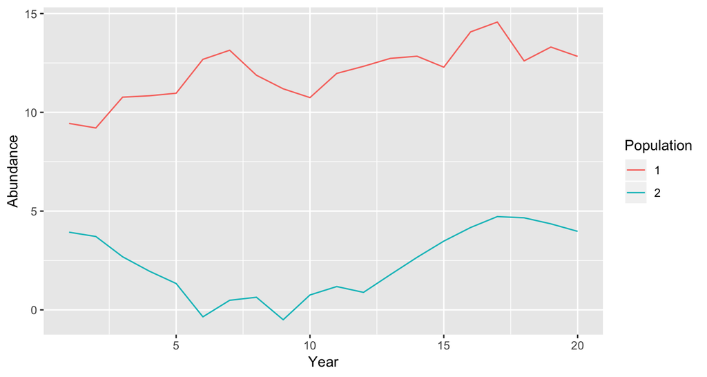

[figure not shown]

## Percent Error Statistics

Percent Error:

\[{ p }_{ t }=\frac { { e }_{ t }\cdot 100 }{ { Y }_{ t } }\]

Mean Absolute Percent Error (MAPE):

\[MAPE\quad =\quad E\left[ \left| { p }_{ t } \right| \right]\] Root Mean Square Percent Error (RMSPE):

\[RMSPE\quad =\quad \sqrt { E\left[ { p }_{ t }^{ 2 } \right] }\]

## Issues with percent error statistics

- What happens when Y = 0?
- Distribution of percent errors tends to be highly skewed / long tails
- MAPE tends to put higher penalty on positive errors
- See Hyndman & Koehler (2006)

## Scaled error statistics

Define scaled error as

\[{ q }_{ t }=\frac { { e }_{ t } }{ \frac { 1 }{ n-1 } \sum _{ i=2 }^{ n }{ \left( { Y }_{ i }-{ Y }_{ i-1 } \right) } }\]

- denominator is MAE from random walk model, so performance is gauged relative to that
- this does not allow for missing data

Absolute scaled error (ASE)

\[ASE=\left| { q }_{ t } \right|\] Mean absolute scaled error (MASE)

\[MASE=E\left[ \left| { q }_{ t } \right| \right]\]

## Interpreting ASE and MASE

All values are relative to the naïve random walk model

- Values < 1 indicate better performance than RW model
- Values > 1 indicate worse performance than RW model

## Implementation in R

- Fit an ARIMA model to ‘airmiles’,holding out last 3 points

```r
n = length(airmiles)
air.model = auto.arima(log(airmiles[1:(n-3)]))
```

## Implementation in R

- Forecast the fitted model 3 steps ahead
- Use holdout data to evaluate accuracy

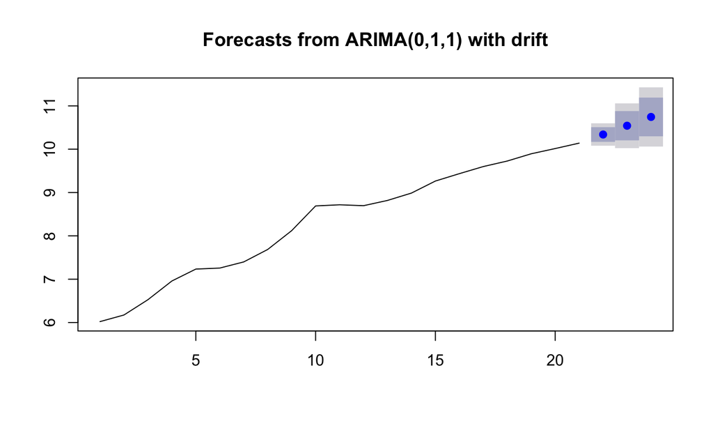

```r
air.forecast = forecast(air.model, h = 3)
plot(air.forecast)
```

## Implementation in R

Evaluate RMSE / MASE statistics for 3 holdouts

```r
accuracy(air.forecast, log(airmiles[(n-2):n]), test = 3)
```

```
##                  ME      RMSE       MAE       MPE     MAPE     MASE
## Test set -0.4183656 0.4183656 0.4183656 -4.051598 4.051598 2.010664
```

Evaluate RMSE / MASE statistics for only last holdout

```r
accuracy(air.forecast, log(airmiles[(n-2):n]), test = 1)
```

```
##                  ME      RMSE       MAE       MPE     MAPE     MASE
## Test set -0.1987598 0.1987598 0.1987598 -1.960106 1.960106 0.955239
```

## Performance metrics summary

Raw statistics (e.g. MSE, RMSE) shouldn’t be applied for data of different scale

Percent error metrics (e.g. MAPE) may be skewed & undefined for real zeroes

Scaled error metrics (ASE, MASE) have been shown to be more robust meta-analyses of many datasets + Hyndman & Koehler (2006)